# Hadi Babalou - 810199380

Artificial Intelligence CA0: *Introduction*  
In this assignment, we are introduced to exploratory data analysis using some of the Python data science libraries such as pandas, NumPy, and matplotlib in Jupyter Notebook.

```python
import pandas as pd
import numpy as np
```

## 1. Describe, Info, Head, and Tail

```python
dataset_path = './Dataset/'
train_df = pd.read_csv(dataset_path + 'train.csv')
```

The `describe()` function is a method that can be called on a pandas DataFrame or Series object in Python. It provides a quick statistical summary of the data, including measures of central tendency, dispersion, and shape of the distribution.

```python
train_df.describe()
```

|  | age | fnlwgt | education-num | capital-gain | capital-loss | hours-per-week |
| --- | --- | --- | --- | --- | --- | --- |
| count | 29825.000000 | 2.982500e+04 | 29825.000000 | 29825.000000 | 29825.000000 | 29825.000000 |
| mean | 38.581425 | 1.897389e+05 | 10.079229 | 1094.586052 | 86.476513 | 40.434334 |
| std | 13.652005 | 1.053738e+05 | 2.571678 | 7485.908646 | 401.195078 | 12.308174 |
| min | 17.000000 | 1.228500e+04 | 1.000000 | 0.000000 | 0.000000 | 1.000000 |
| 25% | 28.000000 | 1.178490e+05 | 9.000000 | 0.000000 | 0.000000 | 40.000000 |
| 50% | 37.000000 | 1.785170e+05 | 10.000000 | 0.000000 | 0.000000 | 40.000000 |
| 75% | 48.000000 | 2.368790e+05 | 12.000000 | 0.000000 | 0.000000 | 45.000000 |
| max | 90.000000 | 1.484705e+06 | 16.000000 | 99999.000000 | 4356.000000 | 99.000000 |

When called on a DataFrame object, the `describe()` function returns a summary of the numerical columns in the DataFrame. This includes following properties for each column:

- count: The number of data entries
- mean: The average of the data
- std: The standard deviation of the data
- min: The minimum value
- 25%: The first quartile of data (25th percentile)
- 50%: The median (50th percentile)
- 75%: The third quartile of data (75th percentile)
- max: The maximum value

The `head()` function is a method that can be called on a pandas DataFrame or Series object in Python. It returns the first n rows of the DataFrame or Series, where n is a specified number (by default n=5).

```python
train_df.head()
```

|  | age | workclass | fnlwgt | education | education-num | marital-status | occupation | relationship | race | sex | capital-gain | capital-loss | hours-per-week | native-country | salary |
| --- | --- | --- | --- | --- | --- | --- | --- | --- | --- | --- | --- | --- | --- | --- | --- |
| 0 | 39 | State-gov | 77516 | Bachelors | 13 | Never-married | Adm-clerical | Not-in-family | White | Male | 2174 | 0 | 40 | United-States | <=50K |
| 1 | 50 | Self-emp-not-inc | 83311 | Bachelors | 13 | Married-civ-spouse | Exec-managerial | Husband | White | Male | 0 | 0 | 13 | United-States | <=50K |
| 2 | 38 | Private | 215646 | HS-grad | 9 | Divorced | Handlers-cleaners | Not-in-family | White | Male | 0 | 0 | 40 | United-States | <=50K |
| 3 | 53 | Private | 234721 | 11th | 7 | Married-civ-spouse | Handlers-cleaners | Husband | Black | Male | 0 | 0 | 40 | United-States | <=50K |
| 4 | 28 | Private | 338409 | Bachelors | 13 | Married-civ-spouse | Prof-specialty | Wife | Black | Female | 0 | 0 | 40 | Cuba | <=50K |

When called on a DataFrame object, the `head()` function returns the first n rows of the DataFrame, which can be useful for quickly examining the structure and contents of the data.

The `tail()` function is a method that can be called on a pandas DataFrame or Series object in Python. It returns the last n rows of the DataFrame or Series, where n is a specified number (by default n=5).

```python
train_df.tail()
```

|  | age | workclass | fnlwgt | education | education-num | marital-status | occupation | relationship | race | sex | capital-gain | capital-loss | hours-per-week | native-country | salary |
| --- | --- | --- | --- | --- | --- | --- | --- | --- | --- | --- | --- | --- | --- | --- | --- |
| 29820 | 48 | Local-gov | 127921 | Bachelors | 13 | Married-civ-spouse | Prof-specialty | Husband | White | Male | 0 | 0 | 40 | United-States | <=50K |
| 29821 | 32 | Private | 42617 | Some-college | 10 | Divorced | Prof-specialty | Not-in-family | White | Female | 0 | 0 | 30 | United-States | <=50K |
| 29822 | 47 | Local-gov | 191389 | HS-grad | 9 | Divorced | Adm-clerical | Unmarried | White | Female | 0 | 0 | 35 | United-States | <=50K |
| 29823 | 38 | Private | 187983 | Prof-school | 15 | Married-civ-spouse | Sales | Wife | White | Female | 0 | 0 | 40 | United-States | <=50K |
| 29824 | 18 | Private | 215110 | HS-grad | 9 | Never-married | Handlers-cleaners | Own-child | Black | Male | 0 | 0 | 40 | United-States | <=50K |

When called on a DataFrame object, the `tail()` function returns the last n rows of the DataFrame, which can be useful for quickly examining the end of the data.

The `info()` function is a method that can be called on a pandas DataFrame object in Python. It provides a concise summary of the DataFrame, including information about the data types of each column, the number of non-null values in each column, and the total memory usage of the DataFrame.

```python
train_df.info()
```

```
<class 'pandas.core.frame.DataFrame'>
RangeIndex: 29825 entries, 0 to 29824
Data columns (total 15 columns):
 #   Column          Non-Null Count  Dtype
---  ------          --------------  -----
 0   age             29825 non-null  int64
 1   workclass       28154 non-null  object
 2   fnlwgt          29825 non-null  int64
 3   education       29825 non-null  object
 4   education-num   29825 non-null  int64
 5   marital-status  29825 non-null  object
 6   occupation      28149 non-null  object
 7   relationship    29825 non-null  object
 8   race            29825 non-null  object
 9   sex             29825 non-null  object
 10  capital-gain    29825 non-null  int64
 11  capital-loss    29825 non-null  int64
 12  hours-per-week  29825 non-null  int64
 13  native-country  29288 non-null  object
 14  salary          29825 non-null  object
dtypes: int64(6), object(9)
memory usage: 3.4+ MB
```

The `info()` function can be useful for quickly understanding the structure of a DataFrame, including the data types of each column and whether there are any missing values. It can also be useful for identifying potential issues with memory usage, as it provides an estimate of the total memory usage of the DataFrame.

## 3. Missing Values

There are several ways to handle missing numerical values in a dataset, some of which include:

- Deleting rows with missing values: This approach simply removes any rows that contain missing values, but it can be problematic if a large portion of the dataset contains missing values.
- Imputing with mean or median: This method involves replacing the missing values with the mean or median of the existing values in that column. This approach can work well if the distribution of the data is normal, but it may not be suitable for skewed data.
- Imputing with regression: This method involves using a regression model to predict the missing values based on other variables in the dataset. This approach can work well if there is a strong correlation between the missing value and other variables in the dataset.
- Using a clustering algorithm: This method involves using clustering algorithms to group similar data points together and then imputing the missing values with the mean or median value of the cluster. This approach can work well if there is a clear clustering structure in the data.
- Using the K-Nearest Neighbors algorithm: This method involves finding the K nearest neighbors of the missing value and imputing the missing value with the average of the K nearest neighbors. This approach can work well if there is a strong correlation between the missing value and its nearest neighbors.

The choice of method depends on the nature of the missing data and the analysis goals.

But in our case, the columns which contain missing values are categorical. There are different ways to handle missing categorical values in a dataset, including:

- Deleting the missing data: If the missing values are a small proportion of the data, you can delete the rows with missing values. However, this may result in a reduction in the size of the dataset and the loss of important information.
- Imputing missing values: You can use various methods to impute missing values in categorical data, such as:
  1. Mode imputation: Replacing missing values with the most common value in the dataset or the most common value in a particular category.
  2. Similarity-based imputation: Replacing missing values with the values of the nearest neighbors in the dataset or a similar subset of the dataset.
  3. Probabilistic imputation: Using probabilistic models to estimate missing values based on the observed data.
- Creating a separate category: If the missing values represent a significant proportion of the data, you can create a separate category to represent the missing values. This can help retain the information in the dataset and prevent the loss of important data.
- Using machine learning algorithms: You can use machine learning algorithms that can handle missing data, such as decision trees and random forests, which can automatically handle missing categorical values during training and testing.

The chosen method should be appropriate for the type and amount of missing data, and it should not introduce any bias or distortions in the analysis.

The `isna()` function gives us a table in which each row gets a true or false value indicating whether the row's value for a column is missing or not.  
Then the `sum()` function counts true values we have in the columns.

```python
train_df.isna().sum()
```

```
age                  0
workclass         1671
fnlwgt               0
education            0
education-num        0
marital-status       0
occupation        1676
relationship         0
race                 0
sex                  0
capital-gain         0
capital-loss         0
hours-per-week       0
native-country     537
salary               0
dtype: int64
```

As we can see, there are 3 columns with missing values in our dataset which are `workclass`, `occupation`, and `native-country`. The portion of missing data in this columns is small, so dropping this columns in not a rational choice here.

```python
train_df['workclass'].value_counts()
```

```
Private             20781
Self-emp-not-inc     2349
Local-gov            1911
State-gov            1181
Self-emp-inc         1032
Federal-gov           882
Without-pay            13
Never-worked            5
Name: workclass, dtype: int64
```

Since the portion of missing data is small and most of the data in `workclass` column belongs to one category, we use mode category to fill the missing values.

```python
mode_category = train_df['workclass'].mode()[0]
train_df['workclass'].fillna(mode_category, inplace=True)
```

```python
train_df['occupation'].value_counts()
```

```
Prof-specialty       3773
Craft-repair         3759
Exec-managerial      3706
Adm-clerical         3491
Sales                3356
Other-service        3029
Machine-op-inspct    1839
Transport-moving     1464
Handlers-cleaners    1244
Farming-fishing       906
Tech-support          849
Protective-serv       582
Priv-house-serv       143
Armed-Forces            8
Name: occupation, dtype: int64
```

Since top frequent categories in `occupation` column have a similar portion of data, we can create a new category for missing values named `Unknown`. another option is to use mode category to fill the missing values and add a new column to indicate if the value is missing or not.

```python
# option 1: fill with 'Unknown'
train_df['occupation'].fillna('Unknown', inplace=True)

# option 2: fill with mode
# mode_category = train_df['occupation'].mode()[0]
# train_df['occupation'+'_imputed'] = np.where(train_df['occupation'].isnull(), 1, 0)
# train_df['occupation'].fillna(mode_category, inplace=True)

# col_list = list(train_df.columns)

# occi = col_list.index('occupation')
# # occi = col_list.find('occupation')

# occii = col_list.index('occupation_imputed')
# # occii = col_list.find('occupation_imputed')

# col_list.insert(occi+1, col_list.pop(occii))
# train_df = train_df[col_list]
# # train_df.reindex(columns=col_list)
```

```python
train_df['native-country'].value_counts()
```

```
United-States                 26713
Mexico                          596
Philippines                     174
Germany                         122
Canada                          115
Puerto-Rico                     112
El-Salvador                      95
India                            94
England                          87
Cuba                             86
South                            76
Jamaica                          73
China                            68
Vietnam                          62
Italy                            62
Dominican-Republic               61
Guatemala                        60
Japan                            56
Poland                           56
Columbia                         54
Taiwan                           48
Haiti                            40
Iran                             40
Portugal                         33
Nicaragua                        31
Peru                             28
Greece                           28
France                           27
Ecuador                          25
Ireland                          23
Thailand                         18
Cambodia                         18
Trinadad&Tobago                  16
Hong                             15
Laos                             15
Yugoslavia                       14
Hungary                          12
Honduras                         12
Outlying-US(Guam-USVI-etc)       11
Scotland                         11
Holand-Netherlands                1
Name: native-country, dtype: int64
```

Since most of the data in `native-country` column belongs to one category, we use mode category to fill the missing values.

```python
mode_category = train_df['native-country'].mode()[0]
train_df['native-country'].fillna(mode_category, inplace=True)
```

```python
train_df.isna().sum()
```

```
age               0
workclass         0
fnlwgt            0
education         0
education-num     0
marital-status    0
occupation        0
relationship      0
race              0
sex               0
capital-gain      0
capital-loss      0
hours-per-week    0
native-country    0
salary            0
dtype: int64
```

The mean is a common method for imputing missing values in data.

Advantages:

- Easy to implement: Mean imputation is a simple and easy-to-implement method that requires minimal programming knowledge.
- Maintains sample size: Mean imputation preserves the original sample size, which can be important for certain statistical analyses.
- Preserves statistical relationships: Mean imputation can preserve some statistical relationships among variables in the data.

Disadvantages:

- Biases the data: Mean imputation can introduce bias into the data, as it assumes that the missing values are similar to the observed values. This may not be true in all cases.
- Reduces variability: Mean imputation reduces the variability of the data, as it replaces missing values with a single value. This can reduce the accuracy of statistical analyses.
- Impacts correlations: Mean imputation can impact correlations among variables in the data, as it tends to increase the correlations among variables. This can lead to misleading results in some cases.

Overall, mean imputation can be a useful method for imputing missing values, but it is important to consider its limitations and potential biases when using it. sometimes it may not make sense and be impossible to use for a column.

## 4. Unique Value Features

`nunique()` is a function in Python's pandas library that returns the number of unique values in a series or a column of a DataFrame. It is often used to get a quick summary of the distinct values in a dataset.

```python
train_df.nunique()
```

```
age                  72
workclass             8
fnlwgt            20337
education            16
education-num        16
marital-status        7
occupation           15
relationship          6
race                  5
sex                   2
capital-gain        118
capital-loss         91
hours-per-week       94
native-country       41
salary                2
dtype: int64
```

As we can see, only `fnlwgt` column has a lot of unique values; but this column's values are not meaningless and they offer useful information to our model. so we won't drop any column in this step.

```python
# train_df.drop(columns=['fnlwgt'], inplace=True)
```

## 5. Dataframe Selection

```python
male_df = train_df.loc[train_df['sex'] == 'Male']
print('Male Count: ', len(male_df))

female_df = train_df.loc[train_df['sex'] == 'Female']
print('Female Count: ', len(female_df))

married_male_df = male_df.loc[male_df['marital-status'] == 'Married-civ-spouse']
print('Married Male Count: ', len(married_male_df))
# print('Married Male Count: ', len(train_df.loc[(train_df['sex'] == 'Male') & (train_df['marital-status'] == 'Married-civ-spouse')]))
```

```
Male Count:  19956
Female Count:  9869
Married Male Count:  12168
```

## 6. Dataframe Selection (2)

```python
display(len(train_df.loc[(train_df['age'] > 30) &
                         (train_df['race'] == 'Black') &
                         (train_df['workclass'] == 'Private')]))
```

```
1373
```

Here, we can see the number of individuals who identify as Black, are over 30 years old, and work in the private sector.

## 7. Mean with Vectorization

```python
def mean_vec():
    return train_df.loc[train_df['education'] == 'Bachelors']['hours-per-week'].mean()

mean_vec()
```

```
42.546669366268475
```

The average number of work hours per week for people with a Bachelor's degree.

## 8. Mean with Loops + Comparison

```python
def mean_loop():
    sum, count = 0, 0
    for i, row in train_df.iterrows():
        if row['education'] == 'Bachelors':
            sum += row['hours-per-week']
            count += 1
    return sum / count

mean_loop()
```

```
42.546669366268475
```

Here we did the same thing using vectorization and loops.  
Now we want to time both and compare them

```python
from timeit import timeit

TIMEIT_LOOPS = 10

tvec = timeit(mean_vec, number=TIMEIT_LOOPS)
tloop = timeit(mean_loop, number=TIMEIT_LOOPS)

print('vectorization:', tvec / TIMEIT_LOOPS)
print('loops:', tloop / TIMEIT_LOOPS)
```

```
vectorization: 0.011554889999933949
loops: 3.2136700200000634
```

This is because vectorization allows computations to be performed on entire arrays or matrices at once, rather than on individual elements using loops. When using loops, the program needs to access each element of the array sequentially, perform the operation, and then move on to the next element. This process is time-consuming, especially when working with large datasets.

In contrast, vectorization allows operations to be performed on entire arrays or matrices at once, without the need for explicit looping. This is because most modern processors are designed to perform mathematical operations on large blocks of data simultaneously, and can take advantage of parallelism to speed up the calculations. Additionally, vectorized code is often optimized at the hardware level, making it much faster than code that uses loops.

## 2. Categorical Label Encoding

Categorical label encoding is a process of converting categorical data into numerical data. There are several approaches for categorical label encoding, including:

- Ordinal Encoding: This approach assigns a unique integer to each category, in a specified order. For example, if we have a categorical variable with three categories (A, B, C), we could assign the integers 1, 2, and 3 to these categories in the order A, B, C. The resulting numerical data can be used in machine learning algorithms that require numerical inputs.
- One-Hot Encoding: This approach creates a binary column for each category, where each row has a 1 in the column corresponding to its category and 0 in all other columns. For example, if we have a categorical variable with three categories (A, B, C), we could create three binary columns labeled A, B, and C, where each row has a 1 in the column corresponding to its category and 0 in all other columns. One-hot encoding is often used for nominal categorical variables, where there is no intrinsic ordering to the categories.
- Binary Encoding: This approach creates binary columns for each category, similar to one-hot encoding, but uses binary code to represent the categories. Binary encoding works by converting each category to a binary number and then using the bits in the binary number as the values for the binary columns. For example, if we have a categorical variable with four categories (A, B, C, D), we could assign the binary values 00, 01, 10, and 11 to these categories, and then create two binary columns labeled C1 and C2, where C1 corresponds to the first bit and C2 corresponds to the second bit.
- Frequency Encoding: This approach assigns a numerical value to each category based on its frequency in the dataset. For example, if we have a categorical variable with three categories (A, B, C), and category A appears in 50% of the rows, category B in 30% of the rows, and category C in 20% of the rows, we could assign the values 0.5, 0.3, and 0.2 to these categories, respectively.
- Target Encoding: This approach assigns a numerical value to each category based on the target variable's mean for that category. For example, if we have a categorical variable with three categories (A, B, C), and we are predicting a binary target variable (0 or 1), we could calculate the mean target value for each category and assign these mean values to the categories. Target encoding can be a powerful technique for categorical data that is highly predictive of the target variable.

Each approach has its advantages and disadvantages, and the choice of encoding method depends on the nature of the data and the requirements of the model.

As we can see in `info()` output, there are 9 categorical columns in our DataFrame which we need to do label encoding on them.

We use Ordinal Encoding for all columns in this particular case.

```python
train_df['sex'] = pd.factorize(train_df['sex'])[0]

# Another way
# train_df['sex'] = train_df['sex'].map({'Male' : 0, 'Female' : 1})

# Another way
# train_df.loc[train_df['sex'] == 'Male',     ['sex']] = 0
# train_df.loc[train_df['sex'] == 'Female',   ['sex']] = 1

# Another way
# train_df['sex'].replace(['Male', 'Female'], [0, 1], inplace=True)

# We can even use One Hot Encoding
# train_df = pd.get_dummies(train_df, columns=['sex'], prefix_sep='')
```

```python
# The missing values will be replaced by -1 if we use pandas.factorize()
train_df['workclass'] = pd.factorize(train_df['workclass'])[0]
train_df['workclass'].replace(to_replace=-1, value=np.nan, inplace=True)

# Another way
# workclass_dic = {
#                 'Private'           : 7,
#                 'Self-emp-not-inc'  : 6,
#                 'Local-gov'         : 5,
#                 'State-gov'         : 4,
#                 'Self-emp-inc'      : 3,
#                 'Federal-gov'       : 2,
#                 'Without-pay'       : 1,
#                 'Never-worked'      : 0
# }
# train_df['workclass'] = train_df['workclass'].map(workclass_dic)
```

```python
train_df['education'] = pd.factorize(train_df['education'])[0]
```

```python
train_df['marital-status'] = pd.factorize(train_df['marital-status'])[0]
```

```python
train_df['occupation'] = pd.factorize(train_df['occupation'])[0]
train_df['occupation'].replace(to_replace=-1, value=np.nan, inplace=True)
```

```python
train_df['relationship'] = pd.factorize(train_df['relationship'])[0]
```

```python
train_df['race'] = pd.factorize(train_df['race'])[0]
```

```python
train_df['native-country'] = pd.factorize(train_df['native-country'])[0]
train_df['native-country'].replace(to_replace=-1, value=np.nan, inplace=True)
```

```python
train_df['salary'] = pd.factorize(train_df['salary'])[0]
```

```python
train_df.head()
```

|  | age | workclass | fnlwgt | education | education-num | marital-status | occupation | relationship | race | sex | capital-gain | capital-loss | hours-per-week | native-country | salary |
| --- | --- | --- | --- | --- | --- | --- | --- | --- | --- | --- | --- | --- | --- | --- | --- |
| 0 | 39 | 0 | 77516 | 0 | 13 | 0 | 0 | 0 | 0 | 0 | 2174 | 0 | 40 | 0 | 0 |
| 1 | 50 | 1 | 83311 | 0 | 13 | 1 | 1 | 1 | 0 | 0 | 0 | 0 | 13 | 0 | 0 |
| 2 | 38 | 2 | 215646 | 1 | 9 | 2 | 2 | 0 | 0 | 0 | 0 | 0 | 40 | 0 | 0 |
| 3 | 53 | 2 | 234721 | 2 | 7 | 1 | 2 | 1 | 1 | 0 | 0 | 0 | 40 | 0 | 0 |
| 4 | 28 | 2 | 338409 | 0 | 13 | 1 | 3 | 2 | 1 | 1 | 0 | 0 | 40 | 1 | 0 |

## 9. Histograms

The `hist()` function in pandas is a method used to generate histograms from data in a pandas DataFrame or Series.  
A histogram is a graphical representation of the distribution of a set of numerical data, where the data is divided into a set of intervals (or "bins") and the count of data points falling within each bin is plotted as a bar.

```
array([[<AxesSubplot:title={'center':'age'}>,
        <AxesSubplot:title={'center':'workclass'}>,
        <AxesSubplot:title={'center':'fnlwgt'}>,
        <AxesSubplot:title={'center':'education'}>],
       [<AxesSubplot:title={'center':'education-num'}>,
        <AxesSubplot:title={'center':'marital-status'}>,
        <AxesSubplot:title={'center':'occupation'}>,
        <AxesSubplot:title={'center':'relationship'}>],
       [<AxesSubplot:title={'center':'race'}>,
        <AxesSubplot:title={'center':'sex'}>,
        <AxesSubplot:title={'center':'capital-gain'}>,
        <AxesSubplot:title={'center':'capital-loss'}>],
       [<AxesSubplot:title={'center':'hours-per-week'}>,
        <AxesSubplot:title={'center':'native-country'}>,
        <AxesSubplot:title={'center':'salary'}>, <AxesSubplot:>]],
      dtype=object)
```

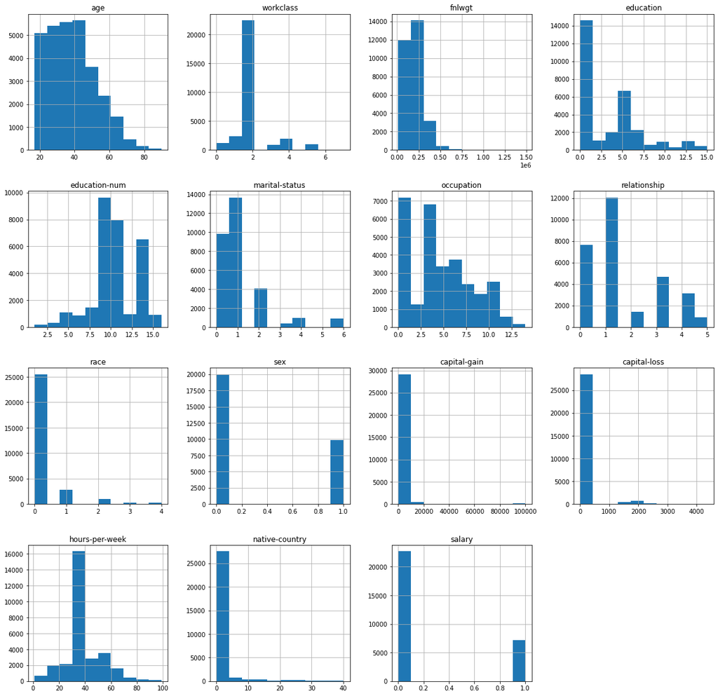

```python
train_df.hist(figsize=(20, 20))
```

## 10. Normalization

```
array([[<AxesSubplot:title={'center':'age'}>,
        <AxesSubplot:title={'center':'workclass'}>,
        <AxesSubplot:title={'center':'fnlwgt'}>,
        <AxesSubplot:title={'center':'education'}>],
       [<AxesSubplot:title={'center':'education-num'}>,
        <AxesSubplot:title={'center':'marital-status'}>,
        <AxesSubplot:title={'center':'occupation'}>,
        <AxesSubplot:title={'center':'relationship'}>],
       [<AxesSubplot:title={'center':'race'}>,
        <AxesSubplot:title={'center':'sex'}>,
        <AxesSubplot:title={'center':'capital-gain'}>,
        <AxesSubplot:title={'center':'capital-loss'}>],
       [<AxesSubplot:title={'center':'hours-per-week'}>,
        <AxesSubplot:title={'center':'native-country'}>,
        <AxesSubplot:title={'center':'salary'}>, <AxesSubplot:>]],
      dtype=object)
```

```
age              -2.283058e-16
workclass        -2.746969e-16
fnlwgt            1.173598e-16
education         1.858028e-16
education-num    -8.496510e-17
marital-status    1.125783e-16
occupation        2.268838e-16
relationship      3.592544e-16
race             -2.017483e-15
sex               4.586254e-16
capital-gain      1.500843e-15
capital-loss     -1.302045e-15
hours-per-week   -3.939575e-16
native-country    5.113819e-16
salary            2.398659e-01
dtype: float64
```

```
age               1.000000
workclass         1.000000
fnlwgt            1.000000
education         1.000000
education-num     1.000000
marital-status    1.000000
occupation        1.000000
relationship      1.000000
race              1.000000
sex               1.000000
capital-gain      1.000000
capital-loss      1.000000
hours-per-week    1.000000
native-country    1.000000
salary            0.427009
dtype: float64
```

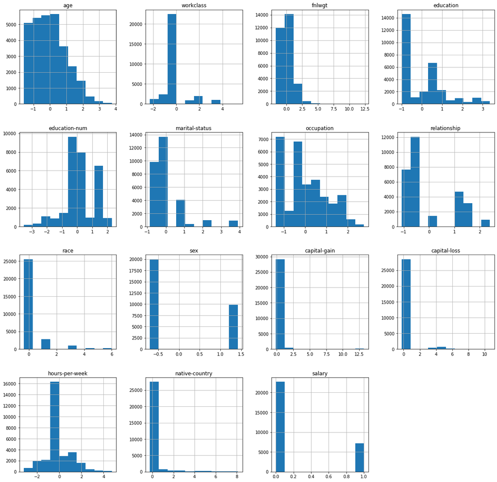

```python
def normalize(df):
    return (df - df.mean()) / df.std()

salary_col = train_df['salary']
train_df = normalize(train_df)
train_df['salary'] = salary_col

display(train_df.hist(figsize=(20, 20)))
display(train_df.mean())
display(train_df.std())
```

As we can see, the data has been normalized and all columns (except for our target column `salary`) have a standard deviation of 1 and a mean of almost 0.

## 11. Plotting PDF to Find the Best Feature

```python
low_df = train_df.loc[train_df['salary'] == 0]
high_df = train_df.loc[train_df['salary'] == 1]

salary_df = pd.DataFrame({
                'low_income_mean':  low_df.mean(),
                'low_income_std':   low_df.std(),
                'high_income_mean': high_df.mean(),
                'high_income_std': high_df.std()
})

salary_df.drop(index=['salary'], inplace=True)
salary_df
```

|  | low_income_mean | low_income_std | high_income_mean | high_income_std |
| --- | --- | --- | --- | --- |
| age | -0.130817 | 1.027893 | 0.414559 | 0.771200 |
| workclass | -0.051843 | 0.904498 | 0.164290 | 1.241397 |
| fnlwgt | 0.004955 | 1.009455 | -0.015702 | 0.969330 |
| education | 0.025847 | 1.012158 | -0.081910 | 0.955917 |
| education-num | -0.187560 | 0.946097 | 0.594376 | 0.931544 |
| marital-status | 0.000341 | 1.103968 | -0.001079 | 0.553958 |
| occupation | 0.057856 | 1.015695 | -0.183344 | 0.925013 |
| relationship | 0.096514 | 1.092388 | -0.305853 | 0.514195 |
| race | 0.039400 | 1.051527 | -0.124860 | 0.802872 |
| sex | 0.121698 | 1.035700 | -0.385660 | 0.757705 |
| capital-gain | -0.125991 | 0.131465 | 0.399265 | 1.976087 |
| capital-loss | -0.082596 | 0.776095 | 0.261746 | 1.473212 |
| hours-per-week | -0.128372 | 0.999179 | 0.406811 | 0.887465 |
| native-country | 0.015597 | 1.036829 | -0.049425 | 0.871313 |

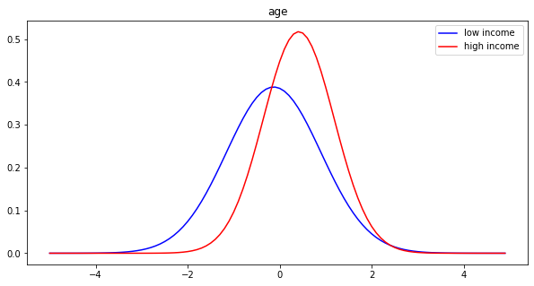

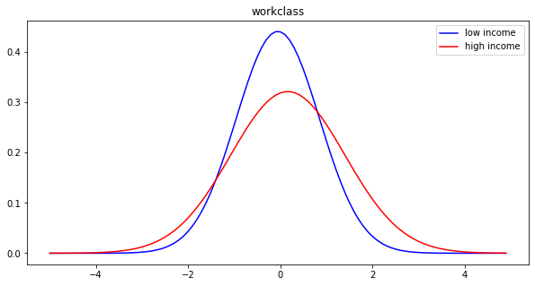

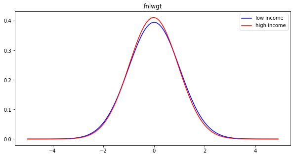

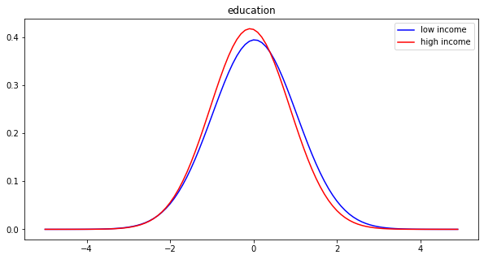

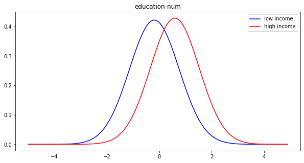

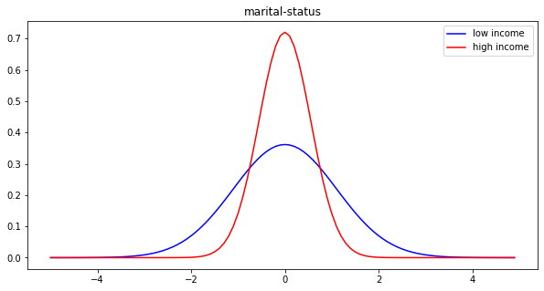

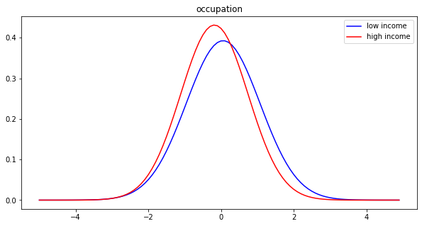

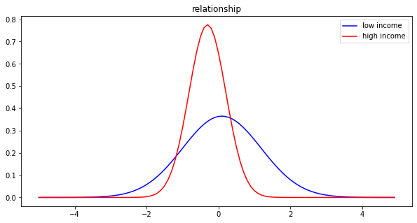

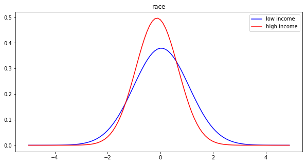

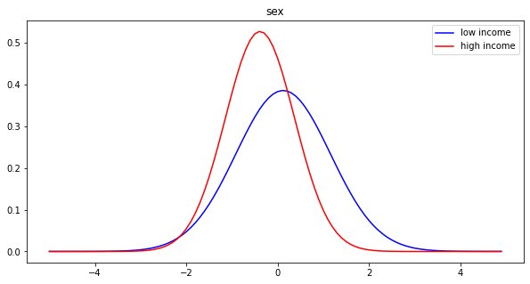

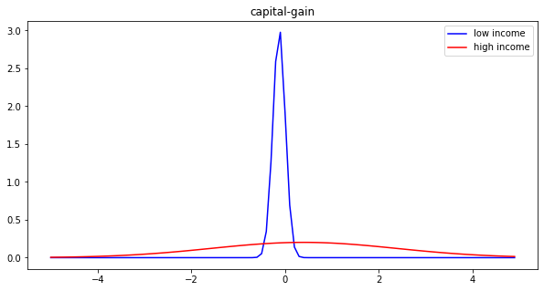

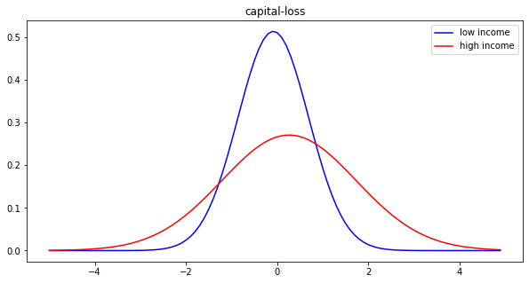

[2 more figures not shown]

```
age               None
workclass         None
fnlwgt            None
education         None
education-num     None
marital-status    None
occupation        None
relationship      None
race              None
sex               None
capital-gain      None
capital-loss      None
hours-per-week    None
native-country    None
dtype: object
```

```python
import numpy
import matplotlib.pyplot as plt
from scipy.stats import norm

intervals = np.arange(-5, 5, 0.1)

def plot_histogram(row):
    plt.figure(figsize=(10, 5))
    plt.title(row.name)

    plt.plot(
        intervals,
        norm.pdf(intervals, loc=row['low_income_mean'], scale=row['low_income_std']),
        label='low income',
        color='blue'
    )

    plt.plot(
        intervals,
        norm.pdf(intervals, loc=row['high_income_mean'], scale=row['high_income_std']),
        label='high income',
        color='red'
    )

    plt.legend()
    plt.show()

salary_df.apply(plot_histogram, axis=1)
```

To know which feature is the best for predicting salary, we should use the one with the most difference between its diagrams for high and low incomes.  
`capital-gain` and `relationship` features can be good candidates for this purpose. both of this features can be seen as rational choices (cause a stable relationship also needs a stable financial state), but we choose `capital-gain` for the rest of our prediction.

## 12. Predicting Salary

```python
test_df = pd.read_csv(dataset_path + 'test.csv')
selected_row = salary_df.loc['capital-gain']

predict_df = test_df.copy()
normalized_capital_gain = normalize(predict_df['capital-gain'])

predict_high_salary_pdf = norm.pdf(normalized_capital_gain, loc=selected_row['high_income_mean'], scale=selected_row['high_income_std'])
predict_low_salary_pdf = norm.pdf(normalized_capital_gain, loc=selected_row['low_income_mean'], scale=selected_row['low_income_std'])
predict_df['salary'] = numpy.where(predict_high_salary_pdf > predict_low_salary_pdf, '>50K', '<=50K')

predict_df.to_csv(dataset_path + 'result.csv', index=False)
display(predict_df[['salary']])
```

|  | salary |
| --- | --- |
| 0 | <=50K |
| 1 | <=50K |
| 2 | <=50K |
| 3 | <=50K |
| 4 | <=50K |
| ... | ... |
| 2731 | <=50K |
| 2732 | <=50K |
| 2733 | <=50K |
| 2734 | <=50K |
| 2735 | >50K |

2736 rows × 1 columns

We used the `capital-gain` feature and predict whether a person has a salary of more than 50k or not.  
We get the PDF for high and low salaries. Then for a specific `capital-gain`, we check if it is in the interval in the PDF where `>50K` is higher or it is in the interval where `<=50K` is higher.  
And finally, we modify `salary` column of predicttion dataframe and write our predictions to `result.csv` file.

Now we compare salary column of test and predict to calculate our model accuracy

```python
is_eq = test_df['salary'].eq(predict_df['salary']).value_counts()
display(is_eq)
print('accuracy:', is_eq[True] / (is_eq[True] + is_eq[False]))
```

```
True     2131
False     605
Name: salary, dtype: int64
```

```
accuracy: 0.778874269005848
```

We got accuracy of 77.89% just by considering `capital-gain` feature which is acceptable.